```python
import pandas as pd
import numpy as np
import os
import glob
import pyarrow

import statsmodels.api as sm
from scipy import stats
from scipy.stats import kstest

import matplotlib.pyplot as plt
from matplotlib import style
from IPython.display import display
```

# Initial exploration of data

We analyse data from 2020–2024, limited to Santiago (RM).

From https://github.com/MinCiencia/Datos-CambioClimatico

- **Air quality** (mpm10, mpm25, no2, o3, so2): 2020–2024

From https://deis.minsal.cl/#datosabiertos

- **Urgencias**
- **Estadísticas hospitalarias**
- **Defunciones**: 2020–2024 — loaded from two files: the 1990–2022 historical extract and the 2023–2026 file.

## Why Parquet + PyArrow?

The urgencia dataset is ~6 GB of CSV across 5 files. Reading it from an HDD takes 10–20 minutes every time the notebook runs. This notebook uses **Parquet** with the **PyArrow** engine to cache the data after the first load, reducing subsequent runs to under 30 seconds.

### How CSV loading works (slow path)

```
Disk → read every byte of every row → parse text → infer types → build DataFrame
```

- `low_memory=False` forces pandas to make a **second pass** to infer column dtypes.
- `encoding="latin-1"` adds decoding overhead byte by byte.
- All columns are loaded even if most aren't needed.

### How Parquet works (fast path)

Parquet is a **columnar binary format**. Instead of storing rows sequentially (like CSV), it stores each column's values together, compressed:

```
┌──────────────┬────────────────┬──────────┬─────┐
│ IdEstacion.. │ GlosaCausa ... │ Total .. │ ... │  ← columns stored separately
└──────────────┴────────────────┴──────────┴─────┘
```

Benefits vs CSV:

- **No text parsing** — values are stored as native binary types (int32, float64, etc.)
- **Schema embedded** — dtypes are stored in the file header, so no type inference pass
- **Compression** — each column compresses well because similar values are adjacent (Snappy codec by default); the 6 GB of CSV becomes ~400 MB
- **Columnar skip** — `usecols` with Parquet actually skips the bytes for unused columns entirely; with CSV it still has to read and discard them

### PyArrow's role

PyArrow is a Python binding to the **Apache Arrow** in-memory format and the **Apache Parquet** library. When you call `pd.read_parquet(...)`, pandas delegates all I/O to PyArrow under the hood:

```
pd.read_parquet("file.parquet")
# → pyarrow.parquet.read_table("file.parquet")
# → converts Arrow columnar buffers → pandas DataFrame
```

The Arrow in-memory representation is the same format PyArrow uses internally, so the conversion to a pandas DataFrame is nearly zero-copy for numeric columns.

### Cache strategy used here

```
First run:  CSV files → pandas → DataFrame → .to_parquet() → cache file on disk
Later runs: cache file → pd.read_parquet() → DataFrame  (skips CSV entirely)
```

The cache is invalidated manually — delete the `.parquet` file if the source CSVs change.

```python
BASE  = "data/Datos-CambioClimatico/output"
YEARS = range(2020, 2025)

# Santiago Metropolitan Region bounding box
# TODO: Check if the coordinates are actually correct
LAT_MIN, LAT_MAX = -34.0, -33.0
LON_MIN, LON_MAX = -71.1, -70.0
JOIN_COLS = ["time", "latitud", "longitud", "codigoEstacion", "nombreEstacion"]

AIR_CACHE = "data/Datos-CambioClimatico/air_santiago_2020_2024.parquet"

if os.path.exists(AIR_CACHE):
    df_air = pd.read_parquet(AIR_CACHE)
    print(f"Air quality loaded from cache: {df_air.shape}")
else:
    def load_pollutant(name):
        dfs = []
        for year in YEARS:
            path = f"{BASE}/{name}/{year}/{year}_{name}.csv"
            if os.path.exists(path):
                dfs.append(pd.read_csv(path, parse_dates=["time"], dtype={"codigoEstacion": str}))
        return pd.concat(dfs, ignore_index=True)

    df_mpm10 = load_pollutant("mpm10_sinca")
    df_mpm25 = load_pollutant("mpm25_sinca")
    df_no2   = load_pollutant("no2_sinca")
    df_o3    = load_pollutant("o3_sinca")
    df_so2   = load_pollutant("so2_sinca")

    pollutants = {"mpm10": df_mpm10, "mpm25": df_mpm25, "no2": df_no2, "o3": df_o3, "so2": df_so2}
    df_air = None
    for name, df in pollutants.items():
        tmp = df.drop(columns="statusCode").rename(columns={"value": name})
        df_air = tmp if df_air is None else df_air.merge(tmp, on=JOIN_COLS, how="outer")

    df_air = df_air[
        df_air["latitud"].between(LAT_MIN, LAT_MAX) &
        df_air["longitud"].between(LON_MIN, LON_MAX)
    ].reset_index(drop=True)

    df_air.to_parquet(AIR_CACHE, index=False, engine="pyarrow")
    print(f"Air quality cached to Parquet: {df_air.shape}")

print("Stations:", df_air["nombreEstacion"].unique())
display(df_air.info())
df_air.head(10)
```

```
Air quality loaded from cache: (426982, 10)
Stations: <ArrowStringArray>
[       'TALAGANTE',        'EL BOSQUE',       'LA FLORIDA',
  'CERRILLOS MOVIL', 'PARQUE O'HIGGINS',         'PUDAHUEL',
      'CERRO NAVIA',    'INDEPENDENCIA',       'LAS CONDES',
     'QUILICURA II',        'CERRILLOS',        'QUILICURA']
Length: 12, dtype: str
<class 'pandas.DataFrame'>
RangeIndex: 426982 entries, 0 to 426981
Data columns (total 10 columns):
 #   Column          Non-Null Count   Dtype
---  ------          --------------   -----
 0   time            426982 non-null  datetime64[us]
 1   latitud         426982 non-null  float64
 2   longitud        426982 non-null  float64
 3   mpm10           377853 non-null  float64
 4   codigoEstacion  426982 non-null  str
 5   nombreEstacion  426982 non-null  str
 6   mpm25           377141 non-null  float64
 7   no2             248501 non-null  float64
 8   o3              294155 non-null  float64
 9   so2             92426 non-null   float64
dtypes: datetime64[us](1), float64(7), str(2)
memory usage: 38.2 MB
```

```
None
```

|  | time | latitud | longitud | mpm10 | codigoEstacion | nombreEstacion | mpm25 | no2 | o3 | so2 |
| --- | --- | --- | --- | --- | --- | --- | --- | --- | --- | --- |
| 0 | 2020-01-01 01:00:00 | -33.673819 | -70.952996 | 2.8 | D28 | TALAGANTE | 2.8 | NaN | NaN | NaN |
| 1 | 2020-01-01 01:00:00 | -33.543945 | -70.663832 | 70.0 | D17 | EL BOSQUE | 19.0 | NaN | NaN | NaN |
| 2 | 2020-01-01 01:00:00 | -33.513468 | -70.585873 | 54.0 | D12 | LA FLORIDA | 27.0 | NaN | NaN | NaN |
| 3 | 2020-01-01 01:00:00 | -33.492549 | -70.712896 | 32.0 | D31 | CERRILLOS MOVIL | 17.0 | NaN | NaN | NaN |
| 4 | 2020-01-01 01:00:00 | -33.461207 | -70.658160 | 44.0 | D14 | PARQUE O'HIGGINS | 12.0 | NaN | NaN | NaN |
| 5 | 2020-01-01 01:00:00 | -33.434877 | -70.747902 | 117.0 | D15 | PUDAHUEL | 33.0 | NaN | NaN | NaN |
| 6 | 2020-01-01 01:00:00 | -33.430224 | -70.729858 | 80.0 | D18 | CERRO NAVIA | 2.8 | NaN | NaN | NaN |
| 7 | 2020-01-01 01:00:00 | -33.419281 | -70.648727 | 55.0 | D11 | INDEPENDENCIA | 22.0 | NaN | NaN | NaN |
| 8 | 2020-01-01 01:00:00 | -33.373799 | -70.522581 | 35.0 | D13 | LAS CONDES | 6.0 | NaN | NaN | NaN |
| 9 | 2020-01-01 01:00:00 | -33.349786 | -70.723752 | 94.0 | D30 | QUILICURA II | 42.0 | NaN | NaN | NaN |

```python
DEFUNCIONES_CACHE  = "data/defunciones/defunciones_2020_2024.parquet"
DEFUNCIONES_HIST   = "data/defunciones/DEFUNCIONES_FUENTE_DEIS_1990_2022_CIFRAS_OFICIALES.csv"
DEFUNCIONES_RECENT = "data/defunciones/DEFUNCIONES_FUENTE_DEIS_2023_2026_31032026.csv"

if os.path.exists(DEFUNCIONES_CACHE):
    df_defunciones = pd.read_parquet(DEFUNCIONES_CACHE, engine="pyarrow")
    print("Defunciones loaded from cache")
else:
    # Historical file is 794 MB — filter to 2020-2022 before concat
    df_hist = pd.read_csv(DEFUNCIONES_HIST, sep=";", encoding="latin-1", low_memory=False)
    df_hist = df_hist[df_hist["AÑO"].between(2020, 2022)]

    df_recent = pd.read_csv(DEFUNCIONES_RECENT, sep=";", encoding="latin-1", low_memory=False)
    df_recent = df_recent[df_recent["AÑO"].between(2023, 2024)]

    df_defunciones = pd.concat([df_hist, df_recent], ignore_index=True)
    del df_hist, df_recent

    df_defunciones.to_parquet(DEFUNCIONES_CACHE, index=False, engine="pyarrow")
    print("Defunciones cached to Parquet")

print("Defunciones 2020–2024:", df_defunciones.shape)
df_defunciones.head()
```

```
Defunciones loaded from cache
Defunciones 2020–2024: (649917, 27)
```

|  | AÑO | FECHA_DEF | SEXO_NOMBRE | EDAD_TIPO | EDAD_CANT | COD_COMUNA | COMUNA | NOMBRE_REGION | DIAG1 | CAPITULO_DIAG1 | ... | DIAG2 | CAPITULO_DIAG2 | GLOSA_CAPITULO_DIAG2 | CODIGO_GRUPO_DIAG2 | GLOSA_GRUPO_DIAG2 | CODIGO_CATEGORIA_DIAG2 | GLOSA_CATEGORIA_DIAG2 | CODIGO_SUBCATEGORIA_DIAG2 | GLOSA_SUBCATEGORIA_DIAG2 | LUGAR_DEFUNCION |
| --- | --- | --- | --- | --- | --- | --- | --- | --- | --- | --- | --- | --- | --- | --- | --- | --- | --- | --- | --- | --- | --- |
| 0 | 2020 | 2020-09-10 | Hombre | 1.0 | 87.0 | 4101.0 | La Serena | De Coquimbo | A419 | A00-B99 | ... | NaN | NaN | NaN | NaN | NaN | NaN | NaN | NaN | NaN | Hospital o Clínica |
| 1 | 2020 | 2020-02-25 | Hombre | 1.0 | 87.0 | 13401.0 | San Bernardo | Metropolitana de Santiago | C229 | C00-D48 | ... | NaN | NaN | NaN | NaN | NaN | NaN | NaN | NaN | NaN | Casa habitación |
| 2 | 2020 | 2020-08-05 | Mujer | 1.0 | 115.0 | 9120.0 | Villarrica | De La Araucanía | C259 | C00-D48 | ... | NaN | NaN | NaN | NaN | NaN | NaN | NaN | NaN | NaN | Casa habitación |
| 3 | 2020 | 2020-06-29 | Mujer | 1.0 | 87.0 | 13301.0 | Colina | Metropolitana de Santiago | C220 | C00-D48 | ... | NaN | NaN | NaN | NaN | NaN | NaN | NaN | NaN | NaN | Casa habitación |
| 4 | 2020 | 2020-06-15 | Hombre | 1.0 | 89.0 | 13117.0 | Lo Prado | Metropolitana de Santiago | F321 | F00-F99 | ... | NaN | NaN | NaN | NaN | NaN | NaN | NaN | NaN | NaN | Casa habitación |

5 rows × 27 columns

```python
URGENCIA_DIR    = "data/urgencias"
HOSPITAL_CONSOL = "data/estadisticas_hospitalarias/Consolidado Estadísticas Hospitalarias 2014-2023.xlsx"
HOSPITAL_2024   = "data/estadisticas_hospitalarias/Estadísticas Hospitalarias Año 2024.xlsx"
URGENCIA_CACHE  = "data/urgencias/urgencia_2020_2024.parquet"
HOSPITAL_CACHE  = "data/estadisticas_hospitalarias/hospitalaria_2020_2024.parquet"

URGENCIA_COLS = {
    "IdEstablecimiento", "NEstablecimiento", "GlosaCausa",
    "Total", "Menores_1", "De_1_a_4", "De_5_a_14", "De_15_a_64", "De_65_y_mas",
    "fecha", "semana", "GLOSATIPOESTABLECIMIENTO", "NombreRegion",
}

if os.path.exists(URGENCIA_CACHE):
    df_urgencia = pd.read_parquet(URGENCIA_CACHE, engine="pyarrow")
    print("Urgencia loaded from cache")
else:
    # Derive RM establishment IDs from 2023 (smallest file that has NombreRegion)
    _ref = pd.read_csv(
        f"{URGENCIA_DIR}/AtencionesUrgencia2023.csv",
        sep=";", encoding="latin-1", low_memory=False,
        usecols=["IdEstablecimiento", "NombreRegion"],
    )
    _rm_ids = set(_ref.loc[_ref["NombreRegion"] == "Metropolitana de Santiago", "IdEstablecimiento"].unique())
    del _ref

    # Load, filter to RM, and free each year before loading the next
    dfs_urg = []
    for year in YEARS:
        print(f"  loading {year}...", end=" ", flush=True)
        df = pd.read_csv(
            f"{URGENCIA_DIR}/AtencionesUrgencia{year}.csv",
            sep=";", encoding="latin-1", low_memory=False,
            usecols=lambda c: c in URGENCIA_COLS,
        )
        df = df[df["IdEstablecimiento"].isin(_rm_ids)]  # filter before concat
        dfs_urg.append(df)
        del df
        print("done")

    df_urgencia = pd.concat(dfs_urg, ignore_index=True)
    del dfs_urg, _rm_ids
    df_urgencia.to_parquet(URGENCIA_CACHE, index=False, engine="pyarrow")
    print("Urgencia cached to Parquet")

if os.path.exists(HOSPITAL_CACHE):
    df_hospitalaria = pd.read_parquet(HOSPITAL_CACHE, engine="pyarrow")
    print("Hospitalaria loaded from cache")
else:
    dfs_hosp = []
    for year in range(2020, 2024):
        df = pd.read_excel(HOSPITAL_CONSOL, sheet_name=str(year), header=2)
        df["año"] = year
        dfs_hosp.append(df)
    df_h24 = pd.read_excel(HOSPITAL_2024, sheet_name="Año 2024", header=2)
    df_h24["año"] = 2024
    dfs_hosp.append(df_h24)
    df_hospitalaria = pd.concat(dfs_hosp, ignore_index=True)
    df_hospitalaria.to_parquet(HOSPITAL_CACHE, index=False, engine="pyarrow")
    print("Hospitalaria cached to Parquet")

print("Urgencia    :", df_urgencia.shape)
print("Hospitalaria:", df_hospitalaria.shape)
```

```
Urgencia loaded from cache
Hospitalaria loaded from cache
Urgencia    : (10259080, 13)
Hospitalaria: (73960, 21)
```

```python
# RM establishment IDs come from 2023-2024 rows that carry NombreRegion
rm_ids = set(
    df_urgencia[
        df_urgencia.get("NombreRegion", pd.Series(dtype=str)).fillna("") == "Metropolitana de Santiago"
    ]["IdEstablecimiento"].unique()
)
df_urgencia_rm = df_urgencia[df_urgencia["IdEstablecimiento"].isin(rm_ids)].copy()
# Derive year from fecha (DD/MM/YYYY) so earlier rows can be filtered by year later
df_urgencia_rm["año"] = pd.to_datetime(df_urgencia_rm["fecha"], dayfirst=True).dt.year
df_urgencia_rm = df_urgencia_rm[df_urgencia_rm["año"].between(2020, 2024)]

df_hospitalaria_rm = df_hospitalaria[
    df_hospitalaria["Nombre SS/SEREMI"].str.startswith("Metropolitano", na=False) &
    (df_hospitalaria["Cód. Nivel Cuidado"] != 0)
]

print("Urgencia RM    :", df_urgencia_rm.shape)
print("Hospitalaria RM:", df_hospitalaria_rm.shape)
print("Servicios RM:", df_hospitalaria_rm["Nombre SS/SEREMI"].unique())
```

```
Urgencia RM    : (10259080, 14)
Hospitalaria RM: (14333, 21)
Servicios RM: <ArrowStringArray>
[      'Metropolitano Norte',   'Metropolitano Occidente',
     'Metropolitano Central',     'Metropolitano Oriente',
         'Metropolitano Sur', 'Metropolitano Sur Oriente']
Length: 6, dtype: str
```

```python
#display(df_mpm10.head())
#display(df_mpm25.head())
#display(df_no2.head())
#display(df_o3.head())
#display(df_so2.head())
display(df_urgencia_rm.head())
display(df_hospitalaria_rm.head())
```

|  | IdEstablecimiento | NEstablecimiento | GlosaCausa | Total | Menores_1 | De_1_a_4 | De_5_a_14 | De_15_a_64 | De_65_y_mas | fecha | semana | GLOSATIPOESTABLECIMIENTO | NombreRegion | año |
| --- | --- | --- | --- | --- | --- | --- | --- | --- | --- | --- | --- | --- | --- | --- |
| 0 | 14-101 | Complejo Hospitalario Dr. Sótero del Río (Sant... | - TRAUMATISMOS Y ENVENENAMIENTOS | 3 | 0 | 0 | 0 | 2 | 1 | 02/10/2020 | 40 | Hospital | NaN | 2020 |
| 1 | 14-101 | Complejo Hospitalario Dr. Sótero del Río (Sant... | - TRAUMATISMOS Y ENVENENAMIENTOS | 7 | 0 | 0 | 2 | 3 | 2 | 03/10/2020 | 40 | Hospital | NaN | 2020 |
| 2 | 14-101 | Complejo Hospitalario Dr. Sótero del Río (Sant... | - TRAUMATISMOS Y ENVENENAMIENTOS | 2 | 0 | 1 | 0 | 1 | 0 | 04/10/2020 | 41 | Hospital | NaN | 2020 |
| 3 | 14-101 | Complejo Hospitalario Dr. Sótero del Río (Sant... | - TRAUMATISMOS Y ENVENENAMIENTOS | 6 | 0 | 0 | 1 | 4 | 1 | 05/10/2020 | 41 | Hospital | NaN | 2020 |
| 4 | 14-101 | Complejo Hospitalario Dr. Sótero del Río (Sant... | - TRAUMATISMOS Y ENVENENAMIENTOS | 3 | 0 | 0 | 0 | 1 | 2 | 06/10/2020 | 41 | Hospital | NaN | 2020 |

|  | Cód. SS/SEREMI | Nombre SS/SEREMI | Cód. Estab. | Nombre Establecimiento | Cód. Nivel Cuidado | Nombre Nivel Cuidado | Glosa | Acum | Ene | Feb | ... | Abr | May | Jun | Jul | Ago | Sep | Oct | Nov | Dic | año |
| --- | --- | --- | --- | --- | --- | --- | --- | --- | --- | --- | --- | --- | --- | --- | --- | --- | --- | --- | --- | --- | --- |
| 3646 | 9 | Metropolitano Norte | 109100 | Complejo Hospitalario San José (Santiago, Inde... | 403 | 403 - Área Médico-Quirúrgico Cuidados Básicos | Dias Cama Disponibles | 65560.00 | 7907.00 | 7395.0 | ... | 7650.0 | 7703.00 | 7218.0 | 3138.00 | 3394.00 | 3308.00 | 3121.00 | 3318.0 | 3503.0 | 2020 |
| 3647 | 9 | Metropolitano Norte | 109100 | Complejo Hospitalario San José (Santiago, Inde... | 403 | 403 - Área Médico-Quirúrgico Cuidados Básicos | Dias Cama Ocupados | 56703.00 | 7698.00 | 7283.0 | ... | 5972.0 | 5611.00 | 5902.0 | 2736.00 | 2748.00 | 2639.00 | 2940.00 | 2999.0 | 3103.0 | 2020 |
| 3648 | 9 | Metropolitano Norte | 109100 | Complejo Hospitalario San José (Santiago, Inde... | 403 | 403 - Área Médico-Quirúrgico Cuidados Básicos | Dias de Estada | 57333.00 | 7860.00 | 7312.0 | ... | 5726.0 | 5749.00 | 5859.0 | 2489.00 | 2778.00 | 2771.00 | 2805.00 | 2670.0 | 3255.0 | 2020 |
| 3649 | 9 | Metropolitano Norte | 109100 | Complejo Hospitalario San José (Santiago, Inde... | 403 | 403 - Área Médico-Quirúrgico Cuidados Básicos | Promedio Cama Disponibles | 179.13 | 255.06 | 255.0 | ... | 255.0 | 248.48 | 240.6 | 101.23 | 109.48 | 110.27 | 100.68 | 110.6 | 113.0 | 2020 |
| 3650 | 9 | Metropolitano Norte | 109100 | Complejo Hospitalario San José (Santiago, Inde... | 403 | 403 - Área Médico-Quirúrgico Cuidados Básicos | Numero de Egresos | 6159.00 | 850.00 | 781.0 | ... | 667.0 | 548.00 | 521.0 | 271.00 | 326.00 | 352.00 | 366.00 | 316.0 | 373.0 | 2020 |

5 rows × 21 columns

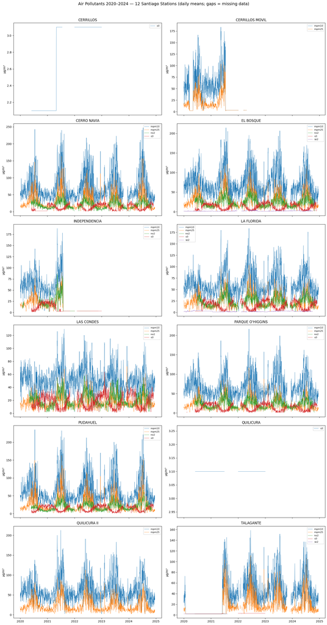

```python
POLLUTANTS = ["mpm10", "mpm25", "no2", "o3", "so2"]
stations = sorted(df_air["nombreEstacion"].unique())

n_stations = len(stations)
n_cols = 2
n_rows = (n_stations + n_cols - 1) // n_cols  # ceil — always enough rows for all stations

fig, axes = plt.subplots(n_rows, n_cols, figsize=(16, n_rows * 5), sharex=True)
axes = axes.flatten()

for ax, station in zip(axes, stations):
    # Resample to daily means so periods with no data become NaN in the index.
    # matplotlib stops drawing a line at NaN, so station downtime appears as a
    # visible gap rather than a straight line connecting the last good reading
    # to the next one (which would falsely imply continuous measurement).
    df_s = (
        df_air[df_air["nombreEstacion"] == station]
        .set_index("time")[POLLUTANTS]
        .resample("1D").mean()
    )
    for pol in POLLUTANTS:
        col = df_s[pol]
        if col.notna().sum() == 0:
            continue
        ax.plot(col.index, col, label=pol, linewidth=0.6)
    ax.set_title(station)
    ax.legend(fontsize=8)
    ax.set_ylabel("µg/m³")
    ax.xaxis.set_major_locator(plt.matplotlib.dates.YearLocator())
    ax.xaxis.set_major_formatter(plt.matplotlib.dates.DateFormatter("%Y"))

for ax in axes[n_stations:]:
    ax.set_visible(False)

fig.suptitle(f"Air Pollutants 2020–2024 — {n_stations} Santiago Stations (daily means; gaps = missing data)", fontsize=14, y=1.01)
plt.tight_layout()
plt.show()
```

```python
print("=" * 60)
print("AIR POLLUTANTS — df_air (Santiago stations, 2020–2024)")
print("=" * 60)
display(df_air[POLLUTANTS].describe().round(2))

print("\nNon-null readings per pollutant per station:")
display(
    df_air.groupby("nombreEstacion")[POLLUTANTS]
    .count()
    .rename(columns=str.upper)
)

print("\n" + "=" * 60)
print("URGENCY CARE — df_urgencia_rm (RM, 2020–2024)")
print("=" * 60)
age_cols = ["Menores_1", "De_1_a_4", "De_5_a_14", "De_15_a_64", "De_65_y_mas"]
display(df_urgencia_rm[["Total"] + age_cols].describe().round(1))

print(f"\nUnique establishments : {df_urgencia_rm['NEstablecimiento'].nunique()}")
print(f"Unique causes         : {df_urgencia_rm['GlosaCausa'].nunique()}")
print(f"Date range            : {df_urgencia_rm['fecha'].min()} → {df_urgencia_rm['fecha'].max()}  ({df_urgencia_rm['año'].min()}–{df_urgencia_rm['año'].max()})")

print("\nTop 10 causes by total attendances:")
display(
    df_urgencia_rm.groupby("GlosaCausa")["Total"]
    .sum()
    .sort_values(ascending=False)
    .head(10)
    .reset_index()
)

print("\n" + "=" * 60)
print("HOSPITAL STATISTICS — df_hospitalaria_rm (RM, 2020–2024)")
print("=" * 60)
month_cols = ["Ene","Feb","Mar","Abr","May","Jun","Jul","Ago","Sep","Oct","Nov","Dic"]
display(df_hospitalaria_rm[["Acum"] + month_cols].describe().round(1))

print(f"\nUnique indicators : {df_hospitalaria_rm['Glosa'].nunique()}")
print(f"Health services   : {list(df_hospitalaria_rm['Nombre SS/SEREMI'].unique())}")

print("\n" + "=" * 60)
print("DEATHS — df_defunciones (2020–2024)")
print("=" * 60)
display(df_defunciones[["EDAD_CANT"]].describe().round(1))

print(f"\nTotal deaths      : {len(df_defunciones):,}")
print(f"By sex:")
display(df_defunciones["SEXO_NOMBRE"].value_counts())

print("\nBy region:")
display(df_defunciones["NOMBRE_REGION"].value_counts())

print("\nTop 10 causes of death (GLOSA_CATEGORIA_DIAG1):")
display(
    df_defunciones["GLOSA_CATEGORIA_DIAG1"]
    .value_counts()
    .head(10)
    .reset_index()
    .rename(columns={"index": "Cause", "GLOSA_CATEGORIA_DIAG1": "Count"})
)
```

```
============================================================
AIR POLLUTANTS — df_air (Santiago stations, 2020–2024)
============================================================
```

|  | mpm10 | mpm25 | no2 | o3 | so2 |
| --- | --- | --- | --- | --- | --- |
| count | 377853.00 | 377141.00 | 248501.00 | 294155.00 | 92426.00 |
| mean | 58.31 | 22.06 | 20.46 | 11.61 | 2.03 |
| std | 44.02 | 21.43 | 15.01 | 15.41 | 0.91 |
| min | 1.00 | 0.00 | 0.06 | 0.10 | 0.35 |
| 25% | 31.00 | 9.00 | 9.14 | 2.10 | 1.18 |
| 50% | 50.00 | 16.00 | 17.75 | 3.10 | 2.05 |
| 75% | 76.00 | 28.00 | 28.25 | 16.04 | 2.43 |
| max | 718.00 | 379.00 | 167.40 | 140.77 | 16.81 |

```
Non-null readings per pollutant per station:
```

| nombreEstacion | MPM10 | MPM25 | NO2 | O3 | SO2 |
| --- | --- | --- | --- | --- | --- |
| CERRILLOS | 0 | 0 | 0 | 18672 | 0 |
| CERRILLOS MOVIL | 18337 | 18380 | 0 | 0 | 0 |
| CERRO NAVIA | 41946 | 41978 | 37399 | 36312 | 0 |
| EL BOSQUE | 41997 | 42006 | 37846 | 36721 | 38785 |
| INDEPENDENCIA | 22462 | 22626 | 15867 | 20448 | 0 |
| LA FLORIDA | 41959 | 40586 | 35927 | 36312 | 39504 |
| LAS CONDES | 43289 | 43427 | 36917 | 36312 | 0 |
| PARQUE O'HIGGINS | 42032 | 42149 | 37328 | 36586 | 0 |
| PUDAHUEL | 42467 | 42561 | 37151 | 36312 | 0 |
| QUILICURA | 0 | 0 | 0 | 18240 | 0 |
| QUILICURA II | 42754 | 42786 | 0 | 0 | 0 |
| TALAGANTE | 40610 | 40642 | 10066 | 18240 | 14137 |

```
============================================================
URGENCY CARE — df_urgencia_rm (RM, 2020–2024)
============================================================
```

|  | Total | Menores_1 | De_1_a_4 | De_5_a_14 | De_15_a_64 | De_65_y_mas |
| --- | --- | --- | --- | --- | --- | --- |
| count | 10259080.0 | 10259080.0 | 10259080.0 | 10259080.0 | 10259080.0 | 10259080.0 |
| mean | 9.0 | 0.3 | 0.8 | 1.4 | 5.4 | 1.2 |
| std | 30.4 | 1.8 | 4.2 | 6.4 | 18.2 | 4.6 |
| min | 0.0 | 0.0 | 0.0 | 0.0 | 0.0 | 0.0 |
| 25% | 0.0 | 0.0 | 0.0 | 0.0 | 0.0 | 0.0 |
| 50% | 0.0 | 0.0 | 0.0 | 0.0 | 0.0 | 0.0 |
| 75% | 2.0 | 0.0 | 0.0 | 0.0 | 1.0 | 0.0 |
| max | 3349.0 | 330.0 | 3179.0 | 306.0 | 1170.0 | 1264.0 |

```
Unique establishments : 158
Unique causes         : 44
```

```
Date range            : 01/01/2020 → 31/12/2024  (2020–2024)

Top 10 causes by total attendances:
```

|  | GlosaCausa | Total |
| --- | --- | --- |
| 0 | TOTAL DEMANDA | 27760913 |
| 1 | SECCIÓN 1. TOTAL ATENCIONES DE URGENCIA | 26560300 |
| 2 | TOTAL DEMÁS CAUSAS | 13725014 |
| 3 | TOTAL CAUSAS SISTEMA RESPIRATORIO | 5972203 |
| 4 | IRA Alta (J00-J06) | 4120236 |
| 5 | TOTAL TRAUMATISMOS Y ENVENENAMIENTO | 3120816 |
| 6 | Otras causas externas | 3059130 |
| 7 | Covid-19, Virus no identificado U07.2 | 1345077 |
| 8 | SECCIÓN 2. TOTAL DE HOSPITALIZACIONES | 812240 |
| 9 | Bronquitis/bronquiolitis aguda (J20-J21) | 730726 |

```
============================================================
HOSPITAL STATISTICS — df_hospitalaria_rm (RM, 2020–2024)
============================================================
```

|  | Acum | Ene | Feb | Mar | Abr | May | Jun | Jul | Ago | Sep | Oct | Nov | Dic |
| --- | --- | --- | --- | --- | --- | --- | --- | --- | --- | --- | --- | --- | --- |
| count | 14333.0 | 14333.0 | 14333.0 | 14333.0 | 14333.0 | 14333.0 | 14333.0 | 14333.0 | 14333.0 | 14333.0 | 14333.0 | 14333.0 | 14333.0 |
| mean | 2985.8 | 258.6 | 233.6 | 260.4 | 245.3 | 262.0 | 267.7 | 271.9 | 269.8 | 258.8 | 265.3 | 255.5 | 262.3 |
| std | 8212.6 | 722.1 | 646.9 | 734.2 | 664.8 | 746.1 | 795.4 | 755.7 | 741.2 | 726.8 | 707.8 | 675.6 | 700.1 |
| min | 0.0 | 0.0 | 0.0 | 0.0 | 0.0 | 0.0 | 0.0 | 0.0 | 0.0 | 0.0 | 0.0 | 0.0 | 0.0 |
| 25% | 8.4 | 2.9 | 2.2 | 2.5 | 2.2 | 2.6 | 2.7 | 2.6 | 2.8 | 2.8 | 2.9 | 2.8 | 2.9 |
| 50% | 74.6 | 18.0 | 16.0 | 17.0 | 16.0 | 17.8 | 18.8 | 18.0 | 19.0 | 18.1 | 19.0 | 18.0 | 18.0 |
| 75% | 1574.0 | 133.0 | 117.0 | 128.0 | 120.0 | 127.0 | 129.0 | 129.8 | 135.0 | 129.0 | 136.0 | 132.0 | 137.0 |
| max | 110952.0 | 15029.0 | 8902.0 | 20379.0 | 9147.0 | 24800.0 | 29456.0 | 24800.0 | 24800.0 | 23814.0 | 10329.0 | 9074.0 | 9472.0 |

```
Unique indicators : 11
Health services   : ['Metropolitano Norte', 'Metropolitano Occidente', 'Metropolitano Central', 'Metropolitano Oriente', 'Metropolitano Sur', 'Metropolitano Sur Oriente']

============================================================
DEATHS — df_defunciones (2020–2024)
============================================================
```

|  | EDAD_CANT |
| --- | --- |
| count | 649909.0 |
| mean | 72.9 |
| std | 18.0 |
| min | 0.0 |
| 25% | 64.0 |
| 50% | 77.0 |
| 75% | 86.0 |
| max | 126.0 |

```
Total deaths      : 649,917
By sex:
```

```
SEXO_NOMBRE
Hombre           342307
Mujer            307562
Indeterminado        48
Name: count, dtype: int64
```

```
By region:
```

```
NOMBRE_REGION
Metropolitana de Santiago                  244605
De Valparaíso                               77366
Del Bíobío                                  59254
Del Maule                                   41233
De La Araucanía                             39788
Del Libertador B. O'Higgins                 35058
De Los Lagos                                32558
De Coquimbo                                 27290
De Ñuble                                    20817
De Antofagasta                              18330
De Los Ríos                                 16634
De Tarapacá                                  9497
De Atacama                                   9301
De Arica y Parinacota                        8656
De Magallanes y de La Antártica Chilena      6372
De Aisén del Gral. C. Ibáñez del Campo       3136
Ignorada                                       22
Name: count, dtype: int64
```

```
Top 10 causes of death (GLOSA_CATEGORIA_DIAG1):
```

|  | Count | count |
| --- | --- | --- |
| 0 | Uso emergente de U07 | 58572 |
| 1 | Infarto agudo del miocardio | 35368 |
| 2 | Hipertensión esencial (primaria) | 18889 |
| 3 | Tumor maligno de los bronquios y del pulmón | 17943 |
| 4 | Otras enfermedades pulmonares obstructivas cró... | 15649 |
| 5 | Tumor maligno del estómago | 15520 |
| 6 | Neumonía, organismo no especificado | 15253 |
| 7 | Enfermedad de Alzheimer | 14576 |
| 8 | Enfermedad cardíaca hipertensiva | 13146 |
| 9 | Tumor maligno del colon | 12571 |

## Air Quality Visualizations

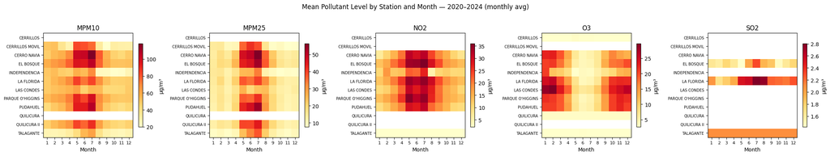

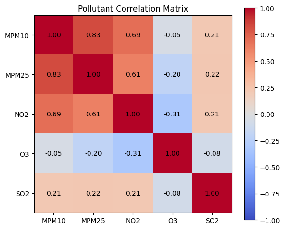

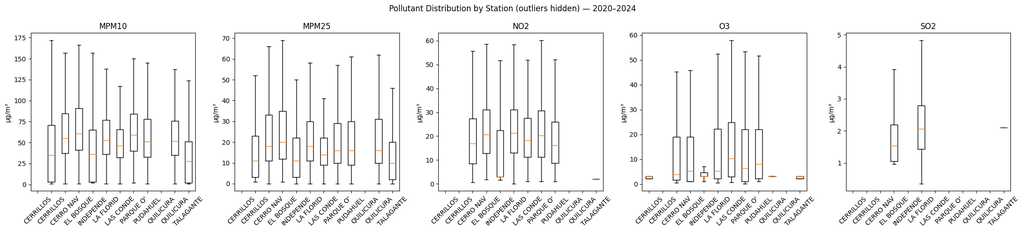

```python
# --- Heatmap: mean pollutant per station per month ---
df_air_m = df_air.copy()
df_air_m["month"] = df_air_m["time"].dt.month
stations_sorted = sorted(df_air["nombreEstacion"].unique())

fig, axes = plt.subplots(1, len(POLLUTANTS), figsize=(22, 4))
for ax, pol in zip(axes, POLLUTANTS):
    pivot = (
        df_air_m.groupby(["nombreEstacion", "month"])[pol]
        .mean()
        .unstack(fill_value=np.nan)
        .reindex(stations_sorted)
    )
    im = ax.imshow(pivot.values, aspect="auto", cmap="YlOrRd")
    ax.set_xticks(range(12))
    ax.set_xticklabels(range(1, 13), fontsize=8)
    ax.set_yticks(range(len(stations_sorted)))
    ax.set_yticklabels(pivot.index, fontsize=7)
    ax.set_title(pol.upper())
    ax.set_xlabel("Month")
    plt.colorbar(im, ax=ax, shrink=0.8, label="µg/m³")
fig.suptitle("Mean Pollutant Level by Station and Month — 2020–2024 (monthly avg)", y=1.02)
plt.tight_layout()
plt.show()

# --- Correlation matrix ---
corr = df_air[POLLUTANTS].corr()
fig, ax = plt.subplots(figsize=(6, 5))
im = ax.imshow(corr.values, cmap="coolwarm", vmin=-1, vmax=1)
labels = [p.upper() for p in POLLUTANTS]
ax.set_xticks(range(len(POLLUTANTS)))
ax.set_yticks(range(len(POLLUTANTS)))
ax.set_xticklabels(labels)
ax.set_yticklabels(labels)
for i in range(len(POLLUTANTS)):
    for j in range(len(POLLUTANTS)):
        ax.text(j, i, f"{corr.iloc[i, j]:.2f}", ha="center", va="center", fontsize=10)
plt.colorbar(im, ax=ax)
ax.set_title("Pollutant Correlation Matrix")
plt.tight_layout()
plt.show()

# --- Box plots per pollutant per station ---
fig, axes = plt.subplots(1, len(POLLUTANTS), figsize=(22, 5))
abbrev = [s[:9] for s in stations_sorted]
for ax, pol in zip(axes, POLLUTANTS):
    data = [df_air[df_air["nombreEstacion"] == s][pol].dropna() for s in stations_sorted]
    ax.boxplot(data, labels=abbrev, showfliers=False)
    ax.set_title(pol.upper())
    ax.set_ylabel("µg/m³")
    ax.tick_params(axis="x", rotation=45)
fig.suptitle("Pollutant Distribution by Station (outliers hidden) — 2020–2024")
plt.tight_layout()
plt.show()
```

## Emergency Care Visualizations

[figure not shown]

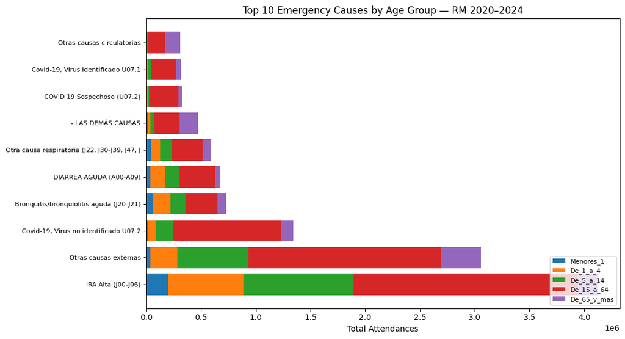

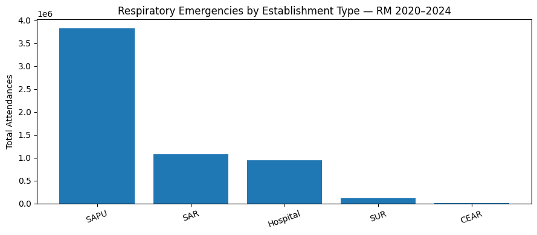

```python
age_cols = ["Menores_1", "De_1_a_4", "De_5_a_14", "De_15_a_64", "De_65_y_mas"]

# --- Weekly respiratory emergency attendances (date-based, 2020-2024) ---
resp_df = df_urgencia_rm[df_urgencia_rm["GlosaCausa"] == "TOTAL CAUSAS SISTEMA RESPIRATORIO"].copy()
resp_df["date"] = pd.to_datetime(resp_df["fecha"], dayfirst=True)
resp_weekly_ts = resp_df.groupby("date")["Total"].sum().sort_index()

fig, ax = plt.subplots(figsize=(15, 4))
ax.plot(resp_weekly_ts.index, resp_weekly_ts.values, linewidth=1.2)
ax.fill_between(resp_weekly_ts.index, resp_weekly_ts.values, alpha=0.2)
ax.set_xlabel("Date")
ax.set_ylabel("Total Attendances")
ax.set_title("Weekly Respiratory Emergency Attendances — RM 2020–2024")
ax.xaxis.set_major_locator(plt.matplotlib.dates.YearLocator())
ax.xaxis.set_major_formatter(plt.matplotlib.dates.DateFormatter("%Y"))
plt.tight_layout()
plt.show()

# --- Stacked bar: top 10 leaf causes by age group (all years) ---
leaf = df_urgencia_rm[
    ~df_urgencia_rm["GlosaCausa"].str.startswith(("TOTAL", "SECCIÓN"), na=False)
]
top_causes = (
    leaf.groupby("GlosaCausa")[age_cols].sum()
    .assign(_total=lambda x: x.sum(axis=1))
    .sort_values("_total", ascending=False)
    .head(10)
    .drop(columns="_total")
)
fig, ax = plt.subplots(figsize=(11, 6))
bottom = np.zeros(len(top_causes))
for col in age_cols:
    ax.barh(range(len(top_causes)), top_causes[col], left=bottom, label=col)
    bottom += top_causes[col].values
ax.set_yticks(range(len(top_causes)))
ax.set_yticklabels([c[:45] for c in top_causes.index], fontsize=8)
ax.set_xlabel("Total Attendances")
ax.set_title("Top 10 Emergency Causes by Age Group — RM 2020–2024")
ax.legend(loc="lower right", fontsize=8)
plt.tight_layout()
plt.show()

# --- Respiratory attendances by establishment type (all years) ---
resp_by_type = (
    df_urgencia_rm[df_urgencia_rm["GlosaCausa"] == "TOTAL CAUSAS SISTEMA RESPIRATORIO"]
    .groupby("GLOSATIPOESTABLECIMIENTO")["Total"].sum()
    .sort_values(ascending=False)
)
fig, ax = plt.subplots(figsize=(9, 4))
ax.bar(resp_by_type.index, resp_by_type.values)
ax.set_ylabel("Total Attendances")
ax.set_title("Respiratory Emergencies by Establishment Type — RM 2020–2024")
ax.tick_params(axis="x", rotation=20)
plt.tight_layout()
plt.show()
```

## Hospital Statistics Visualizations

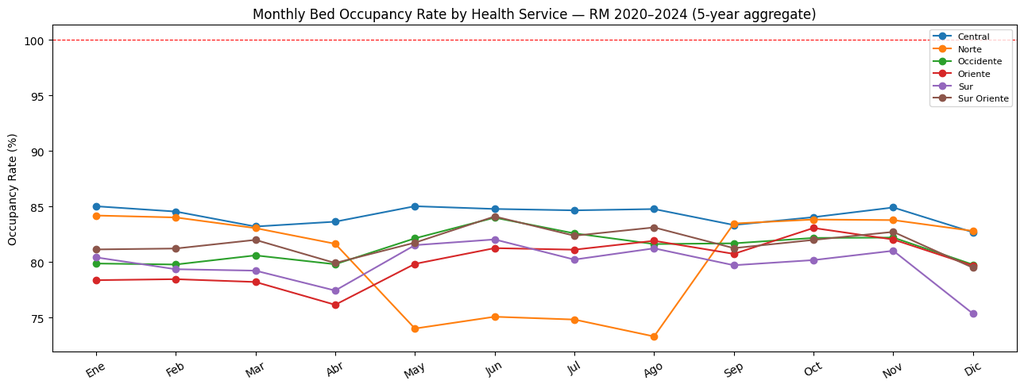

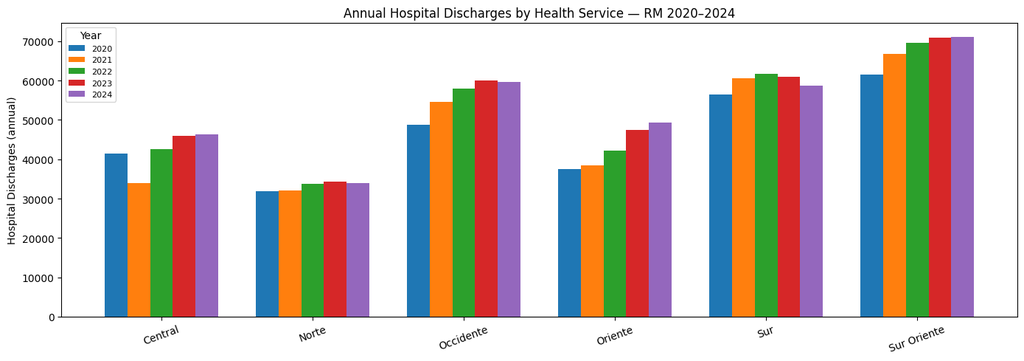

```python
month_cols = ["Ene","Feb","Mar","Abr","May","Jun","Jul","Ago","Sep","Oct","Nov","Dic"]
services = sorted(df_hospitalaria_rm["Nombre SS/SEREMI"].unique())
svc_labels = [s.replace("Metropolitano ", "") for s in services]

# --- Bed occupancy rate by service and month (aggregated over 2020-2024) ---
disponibles = df_hospitalaria_rm[df_hospitalaria_rm["Glosa"] == "Dias Cama Disponibles"]
ocupados    = df_hospitalaria_rm[df_hospitalaria_rm["Glosa"] == "Dias Cama Ocupados"]

fig, ax = plt.subplots(figsize=(13, 5))
for svc, label in zip(services, svc_labels):
    disp = disponibles[disponibles["Nombre SS/SEREMI"] == svc][month_cols].sum()
    ocup = ocupados[ocupados["Nombre SS/SEREMI"] == svc][month_cols].sum()
    rate = (ocup / disp.replace(0, np.nan) * 100)
    ax.plot(range(1, 13), rate.values, marker="o", label=label)
ax.set_xticks(range(1, 13))
ax.set_xticklabels(month_cols, rotation=30)
ax.set_ylabel("Occupancy Rate (%)")
ax.set_title("Monthly Bed Occupancy Rate by Health Service — RM 2020–2024 (5-year aggregate)")
ax.legend(fontsize=8)
ax.axhline(100, color="red", linestyle="--", linewidth=0.8)
plt.tight_layout()
plt.show()

# --- Yearly hospital discharges by service ---
egresos = (
    df_hospitalaria_rm[df_hospitalaria_rm["Glosa"] == "Numero de Egresos"]
    .groupby(["Nombre SS/SEREMI", "año"])["Acum"].sum()
    .unstack(fill_value=0)
    .reindex(services)
)
years_avail = sorted(egresos.columns)
x = np.arange(len(services))
width = 0.15
fig, ax = plt.subplots(figsize=(14, 5))
for i, yr in enumerate(years_avail):
    ax.bar(x + i * width, egresos[yr].values, width, label=str(yr))
ax.set_xticks(x + width * (len(years_avail) - 1) / 2)
ax.set_xticklabels(svc_labels, rotation=20)
ax.set_ylabel("Hospital Discharges (annual)")
ax.set_title("Annual Hospital Discharges by Health Service — RM 2020–2024")
ax.legend(fontsize=8, title="Year")
plt.tight_layout()
plt.show()
```

## Mortality Visualizations

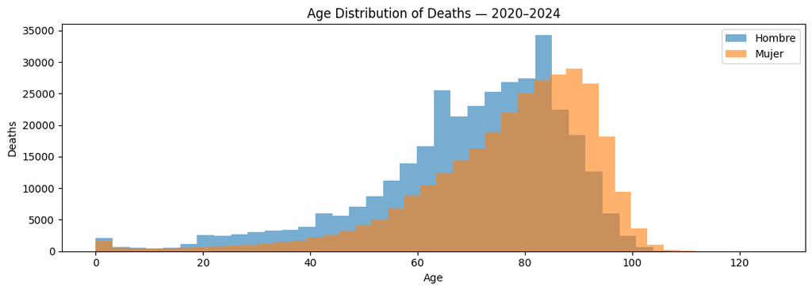

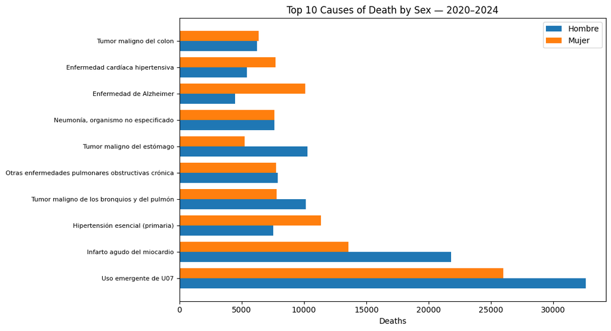

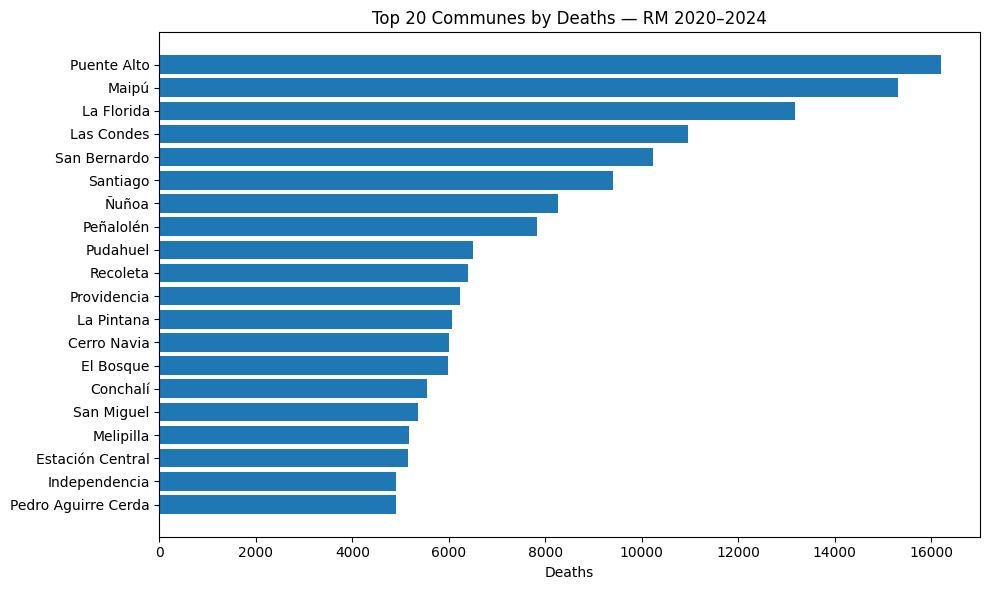

```python
# --- Age distribution by sex ---
fig, ax = plt.subplots(figsize=(11, 4))
for sex, grp in df_defunciones[df_defunciones["SEXO_NOMBRE"] != "Indeterminado"].groupby("SEXO_NOMBRE"):
    ax.hist(grp["EDAD_CANT"], bins=40, alpha=0.6, label=sex)
ax.set_xlabel("Age")
ax.set_ylabel("Deaths")
ax.set_title("Age Distribution of Deaths — 2020–2024")
ax.legend()
plt.tight_layout()
plt.show()

# --- Top 10 causes by sex ---
top10 = df_defunciones["GLOSA_CATEGORIA_DIAG1"].value_counts().head(10).index
df_top = df_defunciones[df_defunciones["GLOSA_CATEGORIA_DIAG1"].isin(top10)]
pivot_sex = (
    df_top.groupby(["GLOSA_CATEGORIA_DIAG1", "SEXO_NOMBRE"]).size()
    .unstack(fill_value=0)
    .reindex(top10)
)
y = np.arange(len(pivot_sex))
width = 0.38
fig, ax = plt.subplots(figsize=(11, 6))
for i, sex in enumerate(["Hombre", "Mujer"]):
    ax.barh(y + (i - 0.5) * width, pivot_sex[sex], width, label=sex)
ax.set_yticks(y)
ax.set_yticklabels([c[:50] for c in pivot_sex.index], fontsize=8)
ax.set_xlabel("Deaths")
ax.set_title("Top 10 Causes of Death by Sex — 2020–2024")
ax.legend()
plt.tight_layout()
plt.show()

# --- Deaths by commune in RM (top 20) ---
def_rm = df_defunciones[df_defunciones["NOMBRE_REGION"] == "Metropolitana de Santiago"]
deaths_commune = def_rm["COMUNA"].value_counts().head(20)
fig, ax = plt.subplots(figsize=(10, 6))
ax.barh(deaths_commune.index[::-1], deaths_commune.values[::-1])
ax.set_xlabel("Deaths")
ax.set_title("Top 20 Communes by Deaths — RM 2020–2024")
plt.tight_layout()
plt.show()
```

## Cross-Dataset Analysis

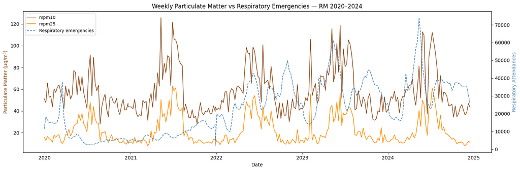

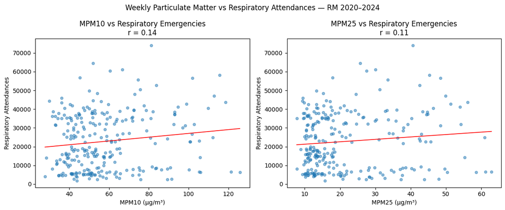

```python
# Build (year, week) indexed air quality series
air_weekly = df_air.copy()
air_weekly["year"] = air_weekly["time"].dt.year
air_weekly["week"] = air_weekly["time"].dt.isocalendar().week.astype(int)
air_weekly_avg = air_weekly.groupby(["year", "week"])[["mpm10", "mpm25"]].mean()

# Build (year, week) indexed urgencia series
resp_df = df_urgencia_rm[df_urgencia_rm["GlosaCausa"] == "TOTAL CAUSAS SISTEMA RESPIRATORIO"].copy()
resp_df["date"] = pd.to_datetime(resp_df["fecha"], dayfirst=True)
resp_df["year"] = resp_df["date"].dt.year
resp_weekly = resp_df.groupby(["year", "semana"])["Total"].sum()
resp_weekly.index.names = ["year", "week"]

combined_w = air_weekly_avg.join(resp_weekly.rename("resp"), how="inner").dropna()
combined_w = combined_w.sort_index()

# fromisocalendar raises ValueError for week 53 in years that only have 52 ISO weeks
# (urgencia uses epidemiological weeks which can reach 53 regardless of ISO calendar).
# Clamping to 52 shifts those ~3 rows by at most 7 days, which is negligible.
combined_w["date"] = combined_w.index.map(
    lambda yw: pd.Timestamp.fromisocalendar(int(yw[0]), min(int(yw[1]), 52), 1)
)

# --- Dual-axis: particulate matter vs respiratory emergencies ---
fig, ax1 = plt.subplots(figsize=(15, 5))
ax2 = ax1.twinx()
ax1.plot(combined_w["date"], combined_w["mpm10"], color="saddlebrown", label="mpm10", linewidth=1.2)
ax1.plot(combined_w["date"], combined_w["mpm25"], color="darkorange",  label="mpm25", linewidth=1.2)
ax2.plot(combined_w["date"], combined_w["resp"],  color="steelblue",  label="Respiratory emergencies", linewidth=1.2, linestyle="--")
ax1.set_xlabel("Date")
ax1.set_ylabel("Particulate Matter (µg/m³)", color="saddlebrown")
ax2.set_ylabel("Respiratory Attendances", color="steelblue")
ax1.set_title("Weekly Particulate Matter vs Respiratory Emergencies — RM 2020–2024")
ax1.xaxis.set_major_locator(plt.matplotlib.dates.YearLocator())
ax1.xaxis.set_major_formatter(plt.matplotlib.dates.DateFormatter("%Y"))
lines1, labels1 = ax1.get_legend_handles_labels()
lines2, labels2 = ax2.get_legend_handles_labels()
ax1.legend(lines1 + lines2, labels1 + labels2, fontsize=9)
plt.tight_layout()
plt.show()

# --- Scatter: weekly mpm10/mpm25 vs respiratory attendances ---
fig, axes = plt.subplots(1, 2, figsize=(12, 5))
for ax, pol in zip(axes, ["mpm10", "mpm25"]):
    ax.scatter(combined_w[pol], combined_w["resp"], alpha=0.5, s=20)
    m, b = np.polyfit(combined_w[pol], combined_w["resp"], 1)
    x_line = np.linspace(combined_w[pol].min(), combined_w[pol].max(), 100)
    ax.plot(x_line, m * x_line + b, color="red", linewidth=1.2)
    r = combined_w[[pol, "resp"]].corr().iloc[0, 1]
    ax.set_xlabel(f"{pol.upper()} (µg/m³)")
    ax.set_ylabel("Respiratory Attendances")
    ax.set_title(f"{pol.upper()} vs Respiratory Emergencies\nr = {r:.2f}")
fig.suptitle("Weekly Particulate Matter vs Respiratory Attendances — RM 2020–2024")
plt.tight_layout()
plt.show()
```

### Seasonal and Temporal Breakdown

The weekly scatter plots above show the aggregate 2020–2024 relationship. The following cells unpack two additional dimensions: **the seasonal cycle** (which months drive the winter peak) and **year-over-year changes** (COVID impact in 2020, recovery, and multi-year pollution trends). A final panel links the extended defunciones data (now 2020–2024) to particulate pollution, allowing direct comparison of respiratory *emergency attendances* vs respiratory *deaths* as health endpoints.

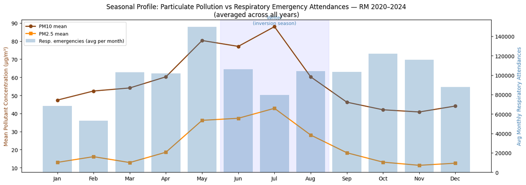

```
Monthly mean PM10 (µg/m³):
month
1     47.4
2     52.4
3     54.1
4     60.3
5     80.3
6     77.1
7     88.0
8     60.2
9     46.2
10    42.0
11    40.8
12    44.1

```

[output cut: 29 more lines]

```python
# --- Seasonal profile (month-of-year): PM vs respiratory emergencies ---
air_monthly_df = df_air.copy()
air_monthly_df["month"] = air_monthly_df["time"].dt.month
pm_monthly = air_monthly_df.groupby("month")[["mpm10", "mpm25"]].mean()

resp_m = df_urgencia_rm[df_urgencia_rm["GlosaCausa"] == "TOTAL CAUSAS SISTEMA RESPIRATORIO"].copy()
resp_m["date"] = pd.to_datetime(resp_m["fecha"], dayfirst=True)
resp_m["month"] = resp_m["date"].dt.month
resp_m["year"] = resp_m["date"].dt.year
# sum per (year, month) then average across years for a representative annual cycle
resp_monthly = resp_m.groupby(["year", "month"])["Total"].sum().groupby("month").mean()

months = list(range(1, 13))
month_labels = ["Jan", "Feb", "Mar", "Apr", "May", "Jun",
                "Jul", "Aug", "Sep", "Oct", "Nov", "Dec"]

fig, ax1 = plt.subplots(figsize=(14, 5))
ax2 = ax1.twinx()
ax1.plot(months, pm_monthly["mpm10"].reindex(months), "o-", color="saddlebrown", linewidth=2, label="PM10 mean")
ax1.plot(months, pm_monthly["mpm25"].reindex(months), "s-", color="darkorange", linewidth=2, label="PM2.5 mean")
ax2.bar(months, resp_monthly.reindex(months), color="steelblue", alpha=0.35, label="Resp. emergencies (avg per month)")
ax1.set_xticks(months)
ax1.set_xticklabels(month_labels)
ax1.set_ylabel("Mean Pollutant Concentration (µg/m³)", color="saddlebrown")
ax2.set_ylabel("Avg Monthly Respiratory Attendances", color="steelblue")
ax1.set_title("Seasonal Profile: Particulate Pollution vs Respiratory Emergency Attendances — RM 2020–2024\n(averaged across all years)")
lines1, labels1 = ax1.get_legend_handles_labels()
lines2, labels2 = ax2.get_legend_handles_labels()
ax1.legend(lines1 + lines2, labels1 + labels2, fontsize=9, loc="upper left")

# Mark Southern Hemisphere winter
ax1.axvspan(5.5, 8.5, alpha=0.07, color="blue", label="_winter")
ax1.text(7, ax1.get_ylim()[1] * 0.97, "Winter\n(inversion season)", ha="center", fontsize=9, color="steelblue")
plt.tight_layout()
plt.show()

print("Monthly mean PM10 (µg/m³):")
print(pm_monthly["mpm10"].round(1).to_string())
print("\nMonthly mean PM2.5 (µg/m³):")
print(pm_monthly["mpm25"].round(1).to_string())
print("\nMonthly avg respiratory attendances (averaged across 2020-2024):")
print(resp_monthly.round(0).astype(int).to_string())
```

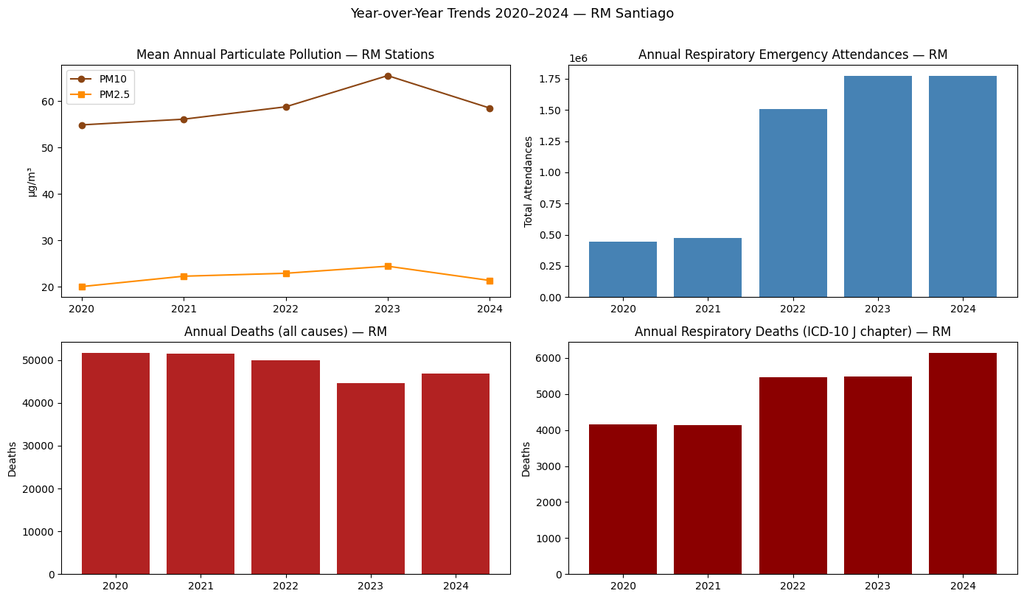

```
Annual mean PM10 (µg/m³):
year
2020    54.9
2021    56.1
2022    58.8
2023    65.5
2024    58.5

Annual mean PM2.5 (µg/m³):
year
2020    20.0
2021    22.3
2022    22.9
2023    24.4
2024    21.4

Total RM respiratory emergency attendances per year:
year
2020     447302
2021     472426
2022    1509971
2023    1771188
2024    1771316

Total RM deaths per year (all causes):
AÑO
2020    51600
2021    51532
2022    49967
2023    44633
2024    46873

Total RM respiratory deaths per year:
AÑO
2020    4161
2021    4136
2022    5474
2023    5479
2024    6133
```

```python
# --- Year-over-year trends: PM, respiratory emergencies, and RM mortality ---
air_annual = df_air.copy()
air_annual["year"] = air_annual["time"].dt.year
pm_annual = air_annual.groupby("year")[["mpm10", "mpm25"]].mean()

resp_annual = df_urgencia_rm[df_urgencia_rm["GlosaCausa"] == "TOTAL CAUSAS SISTEMA RESPIRATORIO"].copy()
resp_annual["date"] = pd.to_datetime(resp_annual["fecha"], dayfirst=True)
resp_annual["year"] = resp_annual["date"].dt.year
resp_by_year = resp_annual.groupby("year")["Total"].sum()

def_rm_all = df_defunciones[df_defunciones["NOMBRE_REGION"] == "Metropolitana de Santiago"]
deaths_by_year = def_rm_all.groupby("AÑO").size()
resp_deaths_by_year = def_rm_all[def_rm_all["CAPITULO_DIAG1"].str.startswith("J", na=False)].groupby("AÑO").size()

years_common = sorted(set(pm_annual.index) & set(resp_by_year.index) & set(deaths_by_year.index))

fig, axes = plt.subplots(2, 2, figsize=(14, 8))

axes[0, 0].plot(pm_annual.index, pm_annual["mpm10"], "o-", color="saddlebrown", label="PM10")
axes[0, 0].plot(pm_annual.index, pm_annual["mpm25"], "s-", color="darkorange", label="PM2.5")
axes[0, 0].set_title("Mean Annual Particulate Pollution — RM Stations")
axes[0, 0].set_ylabel("µg/m³")
axes[0, 0].set_xticks(list(pm_annual.index))
axes[0, 0].legend()

axes[0, 1].bar(resp_by_year.index, resp_by_year.values, color="steelblue")
axes[0, 1].set_title("Annual Respiratory Emergency Attendances — RM")
axes[0, 1].set_ylabel("Total Attendances")
axes[0, 1].set_xticks(list(resp_by_year.index))

axes[1, 0].bar(years_common, deaths_by_year.reindex(years_common).values, color="firebrick")
axes[1, 0].set_title("Annual Deaths (all causes) — RM")
axes[1, 0].set_ylabel("Deaths")
axes[1, 0].set_xticks(years_common)

axes[1, 1].bar(years_common, resp_deaths_by_year.reindex(years_common).values, color="darkred")
axes[1, 1].set_title("Annual Respiratory Deaths (ICD-10 J chapter) — RM")
axes[1, 1].set_ylabel("Deaths")
axes[1, 1].set_xticks(years_common)

fig.suptitle("Year-over-Year Trends 2020–2024 — RM Santiago", fontsize=13, y=1.01)
plt.tight_layout()
plt.show()

print("\nAnnual mean PM10 (µg/m³):")
print(pm_annual["mpm10"].round(1).to_string())
print("\nAnnual mean PM2.5 (µg/m³):")
print(pm_annual["mpm25"].round(1).to_string())
print("\nTotal RM respiratory emergency attendances per year:")
print(resp_by_year.to_string())
print("\nTotal RM deaths per year (all causes):")
print(deaths_by_year.reindex(years_common).to_string())
print("\nTotal RM respiratory deaths per year:")
print(resp_deaths_by_year.reindex(years_common).to_string())
```

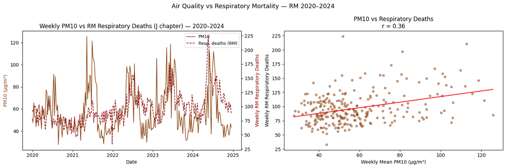

```
Pearson r  (PM10  vs weekly RM respiratory deaths): 0.363
Pearson r  (PM2.5 vs weekly RM respiratory deaths): 0.424
Joint weeks available: 261
```

```python
# --- RM Respiratory Deaths (J chapter) vs Weekly PM10 ---
def_rm_resp = df_defunciones[
    (df_defunciones["NOMBRE_REGION"] == "Metropolitana de Santiago") &
    (df_defunciones["CAPITULO_DIAG1"].str.startswith("J", na=False))
].copy()
def_rm_resp["date"] = pd.to_datetime(def_rm_resp["FECHA_DEF"])
def_rm_resp["year"] = def_rm_resp["date"].dt.year
def_rm_resp["week"] = def_rm_resp["date"].dt.isocalendar().week.astype(int)

resp_deaths_weekly = def_rm_resp.groupby(["year", "week"]).size().rename("resp_deaths")

combined_deaths = air_weekly_avg.join(resp_deaths_weekly, how="inner").dropna()
combined_deaths["date"] = combined_deaths.index.map(
    lambda yw: pd.Timestamp.fromisocalendar(int(yw[0]), min(int(yw[1]), 52), 1)
)
combined_deaths = combined_deaths.sort_values("date")

fig, axes = plt.subplots(1, 2, figsize=(15, 5))

ax1 = axes[0]
ax2 = ax1.twinx()
ax1.plot(combined_deaths["date"], combined_deaths["mpm10"], color="saddlebrown", linewidth=1.2, label="PM10")
ax2.plot(combined_deaths["date"], combined_deaths["resp_deaths"], color="darkred", linewidth=1.2, linestyle="--", label="Resp. deaths (RM)")
ax1.set_xlabel("Date")
ax1.set_ylabel("PM10 (µg/m³)", color="saddlebrown")
ax2.set_ylabel("Weekly RM Respiratory Deaths", color="darkred")
ax1.set_title("Weekly PM10 vs RM Respiratory Deaths (J chapter) — 2020–2024")
ax1.xaxis.set_major_locator(plt.matplotlib.dates.YearLocator())
ax1.xaxis.set_major_formatter(plt.matplotlib.dates.DateFormatter("%Y"))
lines1, labels1 = ax1.get_legend_handles_labels()
lines2, labels2 = ax2.get_legend_handles_labels()
ax1.legend(lines1 + lines2, labels1 + labels2, fontsize=9)

ax = axes[1]
ax.scatter(combined_deaths["mpm10"], combined_deaths["resp_deaths"], alpha=0.5, s=20, color="saddlebrown")
m, b = np.polyfit(combined_deaths["mpm10"], combined_deaths["resp_deaths"], 1)
x_line = np.linspace(combined_deaths["mpm10"].min(), combined_deaths["mpm10"].max(), 100)
ax.plot(x_line, m * x_line + b, color="red", linewidth=1.5)
r_pm10 = combined_deaths[["mpm10", "resp_deaths"]].corr().iloc[0, 1]
ax.set_xlabel("Weekly Mean PM10 (µg/m³)")
ax.set_ylabel("Weekly RM Respiratory Deaths")
ax.set_title(f"PM10 vs Respiratory Deaths\nr = {r_pm10:.2f}")

fig.suptitle("Air Quality vs Respiratory Mortality — RM 2020–2024", fontsize=13)
plt.tight_layout()
plt.show()

r_pm25 = combined_deaths[["mpm25", "resp_deaths"]].corr().iloc[0, 1]
print(f"Pearson r  (PM10  vs weekly RM respiratory deaths): {r_pm10:.3f}")
print(f"Pearson r  (PM2.5 vs weekly RM respiratory deaths): {r_pm25:.3f}")
print(f"Joint weeks available: {len(combined_deaths)}")
```

## Spatial Analysis — Air Stations and Health Establishments

Two spatial questions:

1. **Coverage gaps** — which areas of the RM are far from an air quality monitoring station?
2. **Proximity effect** — do establishments closer to monitoring stations show different respiratory burden than more distant ones?

We assign each establishment its *nearest air station* using a KDTree on lat/lon coordinates (Euclidean distance is a good approximation at this scale — the RM spans ~100 km). The nearest station's mean PM10 (2020–2024) serves as a proxy for the ambient pollution exposure in that establishment's catchment area.

```python
from scipy.spatial import KDTree
import plotly.graph_objects as go

ESTAB_PATH = "data/establecimientos_20260428.csv"
df_estab = pd.read_csv(ESTAB_PATH, sep=";", encoding="utf-8", on_bad_lines="skip")
df_estab["id"] = df_estab["EstablecimientoCodigoAntiguo"].astype(str).str.strip()

df_estab_rm = df_estab[
    (df_estab["RegionCodigo"] == 13) &
    df_estab["Latitud"].notna()
].copy()

# Total respiratory attendances 2020-2024 per establishment
resp_by_estab = (
    df_urgencia_rm[df_urgencia_rm["GlosaCausa"] == "TOTAL CAUSAS SISTEMA RESPIRATORIO"]
    .assign(id=lambda x: x["IdEstablecimiento"].str.strip())
    .groupby("id")["Total"].sum()
    .reset_index(name="resp_total")
)
df_estab_rm = df_estab_rm.merge(resp_by_estab, on="id", how="left")

# Air station mean PM10 across 2020-2024
station_geo = (
    df_air.groupby(["nombreEstacion", "latitud", "longitud"])["mpm10"]
    .mean()
    .reset_index()
    .rename(columns={"mpm10": "mean_pm10"})
)

# Nearest air station for each establishment via KDTree on lat/lon
tree = KDTree(station_geo[["latitud", "longitud"]].values)
dists, idxs = tree.query(df_estab_rm[["Latitud", "Longitud"]].values)
df_estab_rm["nearest_station"] = station_geo["nombreEstacion"].values[idxs]
df_estab_rm["nearest_pm10"]    = station_geo["mean_pm10"].values[idxs]
df_estab_rm["dist_km"]         = dists * 111  # degrees → km approx

print(f"RM establishments with coordinates : {len(df_estab_rm)}")
print(f"Matched to urgencia attendance data: {df_estab_rm['resp_total'].notna().sum()}")
print(f"\nDistance to nearest air station (km):")
print(f"  min={df_estab_rm['dist_km'].min():.1f}  "
      f"mean={df_estab_rm['dist_km'].mean():.1f}  "
      f"max={df_estab_rm['dist_km'].max():.1f}")
print("\nRespiratory burden by nearest station:")
display(
    df_estab_rm.dropna(subset=["resp_total"])
    .groupby("nearest_station")
    .agg(
        resp_total=("resp_total", "sum"),
        n_estab=("resp_total", "count"),
        mean_dist_km=("dist_km", "mean"),
        nearest_pm10=("nearest_pm10", "first"),
    )
    .sort_values("resp_total", ascending=False)
    .round(1)
)
```

```
RM establishments with coordinates : 1069
Matched to urgencia attendance data: 145

Distance to nearest air station (km):
  min=0.1  mean=7.3  max=77.3

Respiratory burden by nearest station:
```

| nearest_station | resp_total | n_estab | mean_dist_km | nearest_pm10 |
| --- | --- | --- | --- | --- |
| EL BOSQUE | 1558149.0 | 34 | 6.9 | 72.1 |
| LA FLORIDA | 816856.0 | 24 | 6.0 | 62.0 |
| TALAGANTE | 666132.0 | 20 | 20.0 | 35.6 |
| CERRILLOS MOVIL | 628291.0 | 11 | 4.8 | 45.5 |
| INDEPENDENCIA | 444619.0 | 14 | 2.9 | 40.6 |
| PUDAHUEL | 396696.0 | 9 | 2.2 | 63.0 |
| PARQUE O'HIGGINS | 368523.0 | 10 | 2.8 | 67.0 |
| QUILICURA II | 305203.0 | 7 | 11.2 | 60.4 |
| CERRO NAVIA | 298278.0 | 8 | 2.5 | 69.9 |
| QUILICURA | 295156.0 | 6 | 12.4 | NaN |
| LAS CONDES | 72329.0 | 2 | 3.9 | 50.8 |

```python
# --- Interactive map: RM health establishments + air quality stations ---
# Uses plotly open-street-map tiles — no API token required

pm_min = station_geo["mean_pm10"].min()
pm_max = station_geo["mean_pm10"].max()

has_resp = df_estab_rm.dropna(subset=["resp_total"]).copy()
no_resp  = df_estab_rm[df_estab_rm["resp_total"].isna()].copy()

# Scale bubble size: sqrt to reduce dominance of very large hospitals
has_resp["bubble"] = (np.sqrt(has_resp["resp_total"]) /
                      np.sqrt(has_resp["resp_total"].max()) * 30 + 5).round(1)

has_resp["hover"] = has_resp.apply(
    lambda r: (f"{r['EstablecimientoGlosa']}<br>"
               f"Type: {r['TipoEstablecimientoGlosa']}<br>"
               f"Resp. attendances: {int(r['resp_total']):,}<br>"
               f"Nearest station: {r['nearest_station']} ({r['dist_km']:.1f} km)<br>"
               f"Station mean PM10: {r['nearest_pm10']:.1f} µg/m³"),
    axis=1,
)
station_geo["hover"] = station_geo.apply(
    lambda r: f"<b>{r['nombreEstacion']}</b><br>Mean PM10: {r['mean_pm10']:.1f} µg/m³",
    axis=1,
)
no_resp["hover"] = no_resp["EstablecimientoGlosa"] + "<br>(no urgencia data)"

fig = go.Figure()

# All other RM establishments — small grey dots
fig.add_trace(go.Scattermapbox(
    lat=no_resp["Latitud"], lon=no_resp["Longitud"],
    mode="markers",
    marker=dict(size=5, color="grey", opacity=0.35),
    text=no_resp["hover"], hoverinfo="text",
    name="Establishment (no urgencia match)",
))

# Urgencia establishments — bubble size ∝ sqrt(resp_total), color = nearest station PM10
fig.add_trace(go.Scattermapbox(
    lat=has_resp["Latitud"], lon=has_resp["Longitud"],
    mode="markers",
    marker=dict(
        size=has_resp["bubble"],
        color=has_resp["nearest_pm10"],
        colorscale="YlOrRd",
        cmin=pm_min, cmax=pm_max,
        colorbar=dict(title="Nearest station<br>mean PM10 (µg/m³)", x=1.02, len=0.6),
        opacity=0.85,
    ),
    text=has_resp["hover"], hoverinfo="text",
    name="Urgencia establishment (bubble = sqrt resp. attendances)",
))

# Air quality stations — large blue circles with labeled text.
fig.add_trace(go.Scattermapbox(
    lat=station_geo["latitud"], lon=station_geo["longitud"],
    mode="markers+text",
    marker=dict(size=20, color="royalblue", opacity=1.0),
    text=station_geo["nombreEstacion"],
    textposition="top right",
    textfont=dict(size=9, color="royalblue"),
    hovertext=station_geo["hover"], hoverinfo="text",
    name="Air quality station",
))

fig.update_layout(
    mapbox_style="open-street-map",
    mapbox=dict(center=dict(lat=-33.47, lon=-70.65), zoom=9.5),
    margin=dict(l=0, r=0, t=50, b=0),
    height=660,
    title=("RM Health Establishments and Air Quality Stations — 2020–2024<br>"
           "<sup>Bubble size = sqrt respiratory attendances | Color = nearest station mean PM10 | Blue = air station</sup>"),
    legend=dict(x=0, y=1, bgcolor="rgba(255,255,255,0.85)"),
)
fig.show()
```

[output not shown]

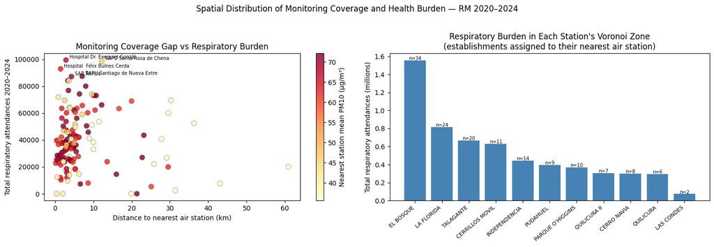

```
Spearman r (distance to station  vs resp. burden) : 0.113  (p=0.178)
Spearman r (nearest station PM10 vs resp. burden) : nan  (p=nan)

Note: resp. burden reflects establishment size and catchment population,
not pollution exposure per se — large referral hospitals dominate the totals.
```

```python
from scipy.stats import spearmanr as _spearmanr

has_resp2 = df_estab_rm.dropna(subset=["resp_total"]).copy()

fig, axes = plt.subplots(1, 2, figsize=(15, 5))

# --- Scatter: distance to nearest station vs respiratory burden ---
ax = axes[0]
sc = ax.scatter(
    has_resp2["dist_km"], has_resp2["resp_total"],
    c=has_resp2["nearest_pm10"], cmap="YlOrRd",
    s=60, alpha=0.8, edgecolors="k", linewidths=0.3,
)
plt.colorbar(sc, ax=ax, label="Nearest station mean PM10 (µg/m³)")
ax.set_xlabel("Distance to nearest air station (km)")
ax.set_ylabel("Total respiratory attendances 2020–2024")
ax.set_title("Monitoring Coverage Gap vs Respiratory Burden")
for _, row in has_resp2.nlargest(5, "resp_total").iterrows():
    ax.annotate(
        row["EstablecimientoGlosa"][:28],
        (row["dist_km"], row["resp_total"]),
        fontsize=7, xytext=(5, 2), textcoords="offset points",
    )

# --- Bar: total respiratory burden per nearest-station Voronoi zone ---
ax2 = axes[1]
station_burden = (
    has_resp2.groupby("nearest_station")
    .agg(resp_total=("resp_total", "sum"), n_estab=("resp_total", "count"))
    .sort_values("resp_total", ascending=False)
)
bars = ax2.bar(range(len(station_burden)), station_burden["resp_total"] / 1e6, color="steelblue")
ax2.set_xticks(range(len(station_burden)))
ax2.set_xticklabels(station_burden.index, rotation=40, ha="right", fontsize=8)
ax2.set_ylabel("Total respiratory attendances (millions)")
ax2.set_title("Respiratory Burden in Each Station's Voronoi Zone\n(establishments assigned to their nearest air station)")
for i, (_, row) in enumerate(station_burden.iterrows()):
    ax2.text(i, row["resp_total"] / 1e6 + 0.005,
             f"n={int(row['n_estab'])}", ha="center", fontsize=7)

fig.suptitle("Spatial Distribution of Monitoring Coverage and Health Burden — RM 2020–2024", y=1.02)
plt.tight_layout()
plt.show()

r_dist,   p_dist   = _spearmanr(has_resp2["dist_km"],       has_resp2["resp_total"])
r_pm_resp, p_pm_resp = _spearmanr(has_resp2["nearest_pm10"], has_resp2["resp_total"])
print(f"Spearman r (distance to station  vs resp. burden) : {r_dist:.3f}  (p={p_dist:.3f})")
print(f"Spearman r (nearest station PM10 vs resp. burden) : {r_pm_resp:.3f}  (p={p_pm_resp:.3f})")
print()
print("Note: resp. burden reflects establishment size and catchment population,")
print("not pollution exposure per se — large referral hospitals dominate the totals.")
```